# Simple Linear Regression Assignment

Garbhan Kenneally, id=21129777

23 November, 2021

## Predicting 3 km Running Times based on laboratory testing.

### Study Description:

Sixteen male well-trained middle and long distance runners performed a 3 km time trial and a number of running tests in the laboratory including their running velocity (km.h-1) at a blood lactate concentration of 4 mmol.l-1 (v4mM) and at their Lactate Threshold (vTlac). All the laboratory testing took place on a motorised treadmill while distance running performance was determined by 3 km time trials on an indoor 200m track.

### Aims:

To investigate whether there is sufficient evidence of a dependency of 3 km running time on v-4mM in the population of male runners of interest in order to use their blood lactate markers (i.e. `v4mM`) to predict their 3km running time (i.e. `Running.Time`).

Response Variable: 3km running time (`Running.Time`) Explanatory Variable: blood lactate markers (`v4mM`)

```r
library(tidyverse)
```

### Read the data and see the few rows

```r
running = read.csv("3krunning.csv", header = TRUE)
head(running)
```

```
##   Running.Time v4mM vTlac Rel.14.5 Rel.16.1 VO2Max
## 1         8.23 20.4  19.5     47.1     52.4   23.4
## 2         8.30 19.5  18.2     48.1     60.0   23.5
## 3         8.62 19.0  17.3     50.3     56.8   22.0
## 4         8.82 18.9  17.8     51.8     56.1   23.0
## 5         9.18 17.8  16.5     48.7     54.1   21.5
## 6         9.23 17.2  15.6     50.5     59.6   20.5
```

### Summary Statistics

Task: Generate the summary statistics for each column in the data and describe the key features of the data.

```r
running %>%
  summarise(
    Mean.time=mean(Running.Time),
    SD.time=sd(Running.Time),
    Mean.v4mM=mean(v4mM),
    SD.v4mM=sd(v4mM))
```

```
##   Mean.time  SD.time Mean.v4mM  SD.v4mM
## 1  9.458125 0.744269  17.06875 1.848141
```

```r
running %>%
  summary()
```

```
##   Running.Time         v4mM           vTlac          Rel.14.5
##  Min.   : 8.230   Min.   :14.20   Min.   :13.50   Min.   :46.50
##  1st Qu.: 9.090   1st Qu.:15.47   1st Qu.:14.55   1st Qu.:49.60
##  Median : 9.390   Median :17.25   Median :16.00   Median :51.15
##  Mean   : 9.458   Mean   :17.07   Mean   :15.95   Mean   :51.59
##  3rd Qu.:10.100   3rd Qu.:18.45   3rd Qu.:17.07   3rd Qu.:53.67
##  Max.   :10.580   Max.   :20.40   Max.   :19.50   Max.   :57.50
##     Rel.16.1         VO2Max
##  Min.   :50.60   Min.   :16.20
##  1st Qu.:55.75   1st Qu.:19.62
##  Median :57.45   Median :21.20
##  Mean   :57.82   Mean   :20.69
##  3rd Qu.:60.42   3rd Qu.:22.07
##  Max.   :64.00   Max.   :23.50
```

From assessing the summary statistics for the data there are are a few key items of interest. The running time column has a relatively small range and deviation. The maximum and minimum time is less than 3 units, and it has a standard deviation of just 0.7442. Following the previous point, it also has a relatively tight Inter-quartile Range between a 1stQu of 9.090 and a 3rdQu of 10.1. This may suggest a lot of players performed similarly for the 3Km run.

For the Blood lactate concentration (v4mM) it has a mean of 17.068 milimoles and a standard deviation of 1.848.

The max and min of our explanatory variable is also worth noting. With linear models it is bad practice to use input values outside of the range of the explanatory variable. For example, you can’t predict the `Running.Time` given a `v4mM` above 20.40 or below 14.20.

### Scatterplot

Task: Generate the scatterplot of `v4mM` vs `Running.Time` and interpret it.

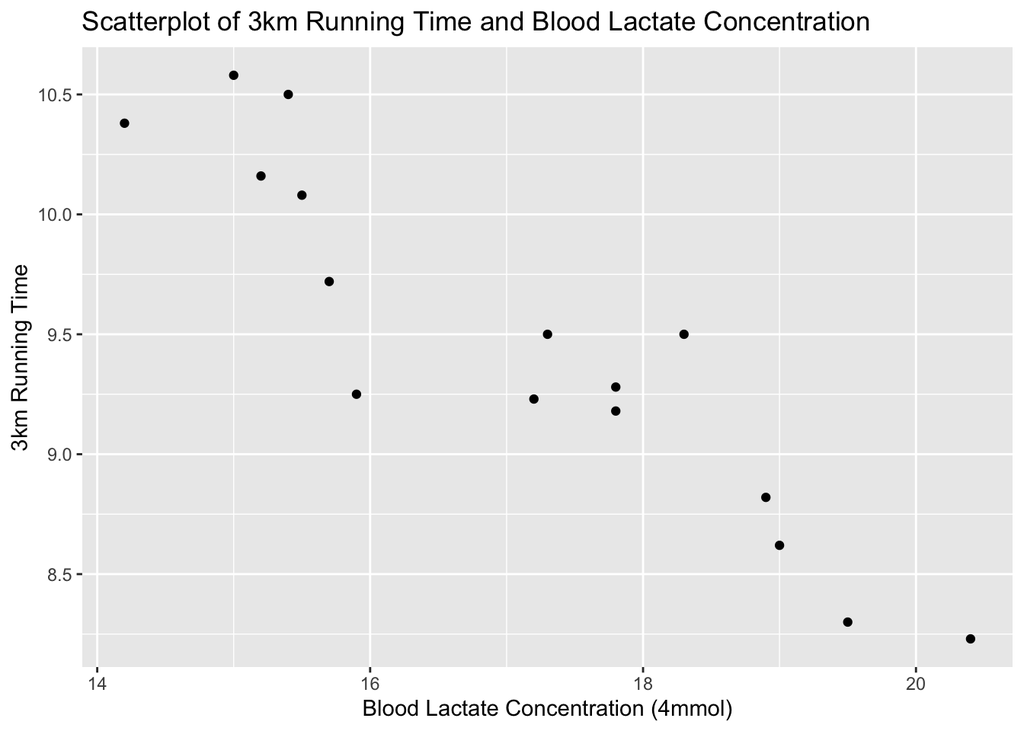

```r
ggplot(running, aes(x=v4mM, y=Running.Time)) +
  geom_point() +
  labs(x = "Blood Lactate Concentration (4mmol)", y = "3km Running Time",
       title = "Scatterplot of 3km Running Time and Blood Lactate Concentration")
```

There does seem to be some spread around the middle of the data between 9.0 and 9.5 `Running.Time`. There is one player above and one player below the trend in the data. Within that time threshold there also seems to be some what of a cluster of similar results. The reason for that slight clustering should be investigated further.

### Scatterplot with smoother.

Task: Add a smooth line to the scatter plot produced in the previous task, and include the new graphs below.

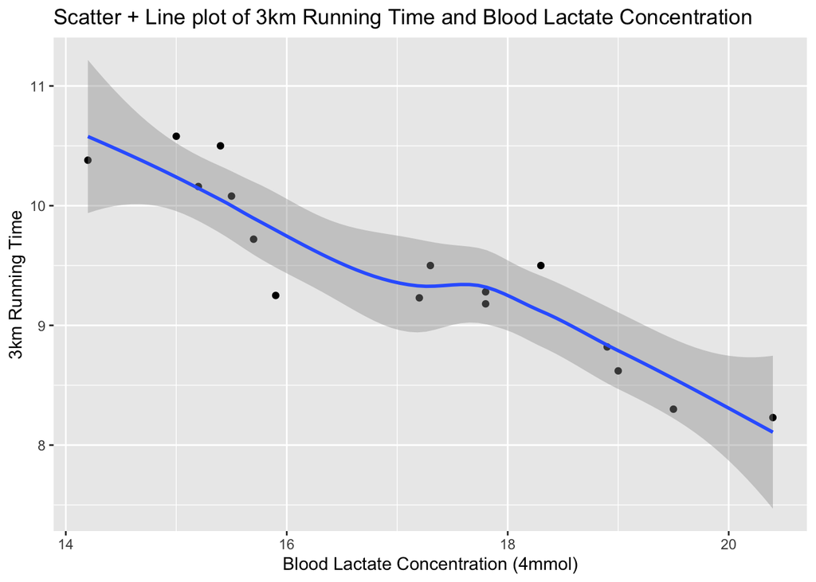

```r
ggplot(running, aes(x=v4mM, y=Running.Time)) +
  geom_point() +
  geom_smooth() +
  labs(x = "Blood Lactate Concentration (4mmol)", y = "3km Running Time",
       title = "Scatter + Line plot of 3km Running Time and Blood Lactate Concentration")
```

Task: What does the smoother suggest regarding the suitability of a simple linear regression model in this context?

The smoother suggests that the data is mostly linear and it is very plausible that a linear model would work well to predict 3km Running time given a certain blood lactate concentration. There does seem to be a slight kink in the line around the small cluster I mentioned earlier. That being said, the smooth line does seem to be pulled into a kink based on one outlier value at the point just below `v4mM=16`.

## Correlation coefficient

Task: calculate the correlation coefficient between `v4mM` vs `Running.Time` and interpret it.

```r
running %>%
  select(v4mM, Running.Time) %>%
  cor()
```

```
##                   v4mM Running.Time
## v4mM          1.000000    -0.925857
## Running.Time -0.925857     1.000000
```

## Scatterplot with line of best fit

Task: Add the line of best fit to the scatter plot produced above and interpret it.

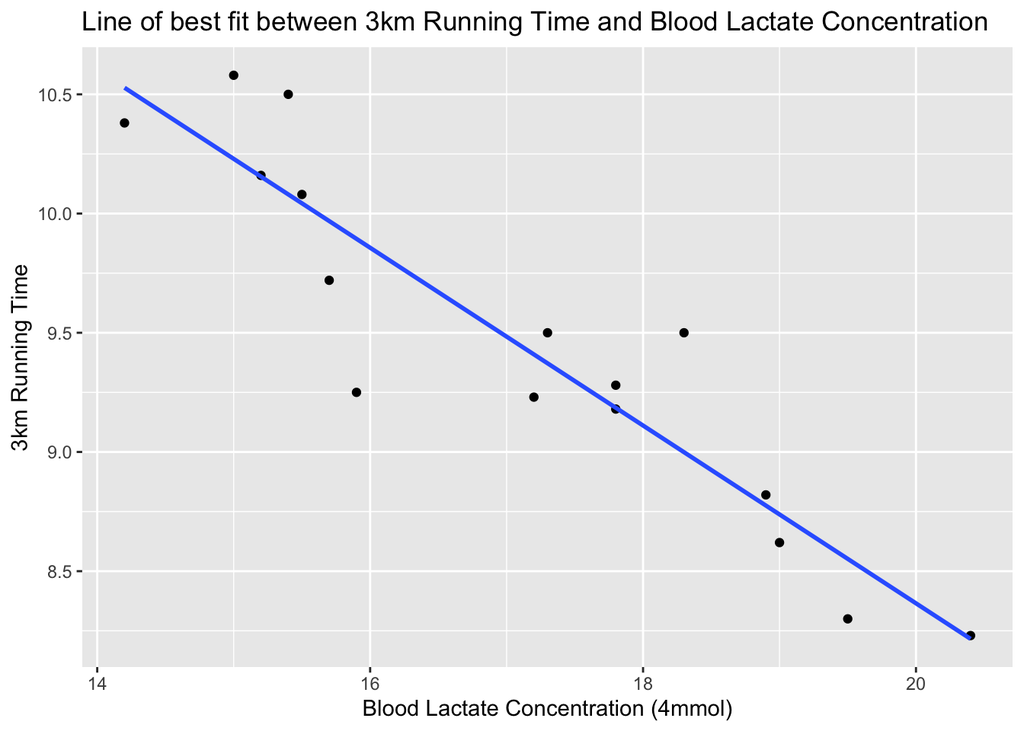

```r
ggplot(running, aes(y = Running.Time, x = v4mM)) +
  geom_point() +
  geom_smooth(method = "lm", se = FALSE) +
  labs(x = "Blood Lactate Concentration (4mmol)", y = "3km Running Time",
       title = "Line of best fit between 3km Running Time and Blood Lactate Concentration")
```

### Fitting a Simple Linear Regression Model

Task: Fit a simple linear regression model to assess the dependence of 3 km running time on v-4mM in the population of male runners.

```r
running.model = lm(Running.Time ~ v4mM, running)
running.model
```

```
##
## Call:
## lm(formula = Running.Time ~ v4mM, data = running)
##
## Coefficients:
## (Intercept)         v4mM
##     15.8223      -0.3729
```

## Equation of line of best fit

Task: Write down the equation of the line of best fit and also provide an interpretation of the slope and intercept of the corresponding line of best fit. Justify if the intercept is or is not a useful quantity in this application.

b0 is intercept The intercept $\beta_0$ is 15.8223. This means that the line of best fit cuts the $Y$ axis when $X$ = 0. In terms of the dataset, this means that the `Running.Time` value would be 15.8223 when blood lactate concentration in 0. This intercept is not really useful in terms this application as it is impossible or highly irregular to have a blood lactate concentration of 0 as it is a natural feature of human biology. A report from University of California Davis on blood lactate states…

> “The concentration of blood lactate is usually 1-2 mmol/L at rest…” [source](https://health.ucdavis.edu/sportsmedicine/resources/lactate.html)

# Make some predictions

Task: Predict the running time (i.e. `Running.Time`) when the blood lactate markers (i.e. `v4mM`) are 14, 15, 16, 17, 18, 19 and 20 mmol.l-1. For each of the predictions produce the confidence intervals and prediction intervals and interpret the results carefully.

```r
v4mM.14to20 = data.frame(
  v4mM = c(14:20)
)
```

```r
predict(running.model, newdata = v4mM.14to20, interval = "confidence")
```

```
##         fit       lwr       upr
## 1 10.602320 10.292450 10.912191
## 2 10.229467  9.990868 10.468065
## 3  9.856613  9.674799 10.038426
## 4  9.483759  9.327551  9.639966
## 5  9.110905  8.934940  9.286869
## 6  8.738051  8.508390  8.967712
## 7  8.365197  8.065626  8.664767
```

Predicting the Confidence interval with the `running.model` gives us 3 columns, `fit`, `lwr`, and `upr`. The confidence interval reflects uncertainty around *mean* prediction values. `Fit` is the regular line of best fit for the input datapoints in the dataframe `v4mM.14to20`, this is the same line as we saw earlier in the ‘Line of Best Fit’ plot. Each of the 7 rows in the returned dataframe is one of the values we passed in as part of the `v4mM.14to20` dataframe.

The `lwr` and `upr` confidence columns show the upper and lower confidence limits for the expected values with 95% confidence. 95% of the data is expected to lie between the `lwr` and `upr` values for each data point.

```r
predict(running.model, newdata = v4mM.14to20, interval = "prediction")
```

```
##         fit      lwr       upr
## 1 10.602320 9.905285 11.299356
## 2 10.229467 9.561059 10.897874
## 3  9.856613 9.206309 10.506916
## 4  9.483759 8.840144 10.127373
## 5  9.110905 8.462212  9.759598
## 6  8.738051 8.072781  9.403320
## 7  8.365197 7.672678  9.057715
```

The prediction interval gives uncertainty around a single value. For our prediction interval it means that 95% of the players with a `v4mM` of 14 will have a 3km Run performance between 9.905 and 11.2999.

# Plots with prediction intervals

Task: Add the produced confidence and prediction intervals to the scatter plot with the line of best fit and interpret it.

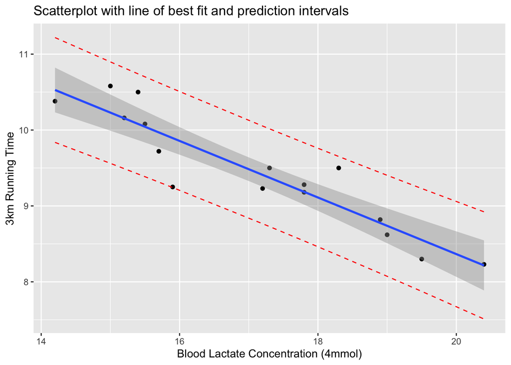

```r
pred.int = predict(running.model, newdata = running, interval = "prediction")

running.df2 = cbind(running, pred.int) # store predictions alongside original dataset

ggplot(running.df2, aes(y = Running.Time, x = v4mM)) +
  geom_point() +
  stat_smooth(method = lm) +
  geom_line(aes(y = lwr), color = "red", linetype = "dashed") + # 3. Add prediction intervals
  geom_line(aes(y = upr), color = "red", linetype = "dashed") +
  labs(x = "Blood Lactate Concentration (4mmol)", y = "3km Running Time",
       title = "Scatterplot with line of best fit and prediction intervals")
```

The confidence interval is the gray areas either side of the line of best fit (blue). The red dashed lines from `pred.int` above and below the line of best fit are the `upr` and `lwr` bounds of the prediction interval. The bounds of the confidence interval are significantly tighter than the one for the prediction interval but that is to be expected.

All of the data points lie within the bounds of the prediction interval, with the one outlier value we made note of in the EDA phase being the only point on the edge.

# More prediction

Task: Predict the running time (i.e. `Running.Time`) when the blood lactate markers (i.e. `v4mM`) are 18.9 mmol.l-1.

```r
predict(running.model, newdata = data.frame(v4mM = 18.9))
```

```
##        1
## 8.775336
```

Task: Why is the result here is different from 8.82, the value in the heading of the data presented above. i.e. the running time when the blood lactate markers (i.e. `v4mM`) are 18.9 mmol.l-1?

The values are similar but different because the value 8.775336 is based off of the line of best fit of our `running.model`. Unlike the linear model we have constructed, the information found in the heading of the data presented was actual test results from the study. The linear model is just a line of best fit where the sum of squared residuals is lowest, and is used to make inference. In this case, the inferred `Running.Time` was an approximation based on the existing datapoints.

Task: Predict the running time (i.e. `Running.Time`) when the blood lactate markers (i.e. `v4mM`) are 2.6 mmol.l-1. Explain if you have any concern related to this prediction?

```r
predict(running.model, newdata = data.frame(v4mM = 2.6))
```

```
##        1
## 14.85286
```

```r
min(running$v4mM)
```

```
## [1] 14.2
```

There are concerns around the usefulness of this predicted value because it is generally bad practice to extrapolate beyond the range of the data. As you can see in the above cell, within our dataset of 16 players the lowest value of blood lactate concentration is 14.2. Extrapolating outside the range of the data we used to train the model as it may no longer hold true. Changing the input data will change the intercept and slope, thus changing the model.

### Overall Conclusion

Task: State your overall conclusions from the modelling of the association between running time and the blood lactate marker.

I would conclude that there is sufficient evidence of a dependency of 3km running time on v-4mM in the population of male runners in the study in order to use their blood lactate markers to predict their 3km running time.

There is a clear association between the amount of `v4mM` in a player’s blood and their performance in the 3km run. The relationship is strongly negatively correlated, meaning that the datapoints move consistently in a downward slope as the `X` variable increases (Blood Lactate Concentration). The high Pearson’s correlation coefficient supports this conclusion.

The data was very plausibly linear so a Simple Linear Regression model was created. After assessing the prediction interval I conclude that the model is sufficient evidence for this to be used to predict running times. That being said I would avoid using input values outside the bounds of what the model was trained on.